# STAT 115 Lab 11

TCGA, Tumor Subtypes, Methylation, Survival Analysis

Andy Shi

April 16-18, 2019

```r
library(FirebrowseR) # new package
library(bladderbatch)
library(limma)
library(sva)
library(dplyr)
library(survival)
library(glmnet)
library(ggplot2)
library(survminer) # new package
```

### Overview of Homework 6

- Part I: Accessing Data from TCGA
- Part II: Tumor Subtype Analysis
  - LIMMA to analyze differential gene expression and methylation
  - K-Means clustering
  - PCA for visualization
  - Survival analysis:
    - Kaplan-Meier curves
    - Cox model
    - Gene signatures
- Part III: Mutation Analysis
  - Mutation Counting
  - CRAVAT: new this year (next week)
- Part IV: CRISPR Screens
  - How to run MAGeCK
- Part V: Cancer immunology

### Part I, Q1. TCGA Website

- TCGA’s website contains raw data that you can download
- Should be fairly straightforward, involves searching on the provided website.

### Part I, Q2: Installing FirebrowseR

- In R, execute: `devtools::install_github("mariodeng/FirebrowseR")`
- If devtools not installed, `install.packages("devtools")`, and then try again.

### Part I, Q2. Broad Firehose

- Contains processed data that you can download and analyze
- Access using firebrowse
- R API: FirebrowseR
- Code adapted from FirebrowseR vignette: https://github.com/mariodeng/FirebrowseR
- Let’s download all breast cancer patients’ clinical data.

```r
# download all available cohorts
cohorts <- Metadata.Cohorts(format = "csv")
# show what cohorts are available
#cohorts

# have to do this because we can only receive 150 patients at a time
all.Received <- FALSE
page.Counter <- 1
page.size <- 150
brca_pats <- list()
while(all.Received == FALSE) {
    brca_pats[[page.Counter]] <- Samples.Clinical(format = "csv",
            cohort = "BRCA", page_size = page.size, page = page.Counter)
    if(page.Counter > 1) {
        colnames(brca_pats[[page.Counter]]) <-
            colnames(brca_pats[[page.Counter-1]])
    }

    if(nrow(brca_pats[[page.Counter]]) < page.size) {
        all.Received = TRUE
    } else {
        page.Counter = page.Counter + 1
    }
}

brca_pats <- do.call(rbind, brca_pats)
dim(brca_pats)
```

```
## [1] 1097  111
```

### Part II, Q1-Q4: Tumor Subtype Analysis

- Q1: Using LIMMA to find differentially expressed genes. Please review previous labs.
- Q2: Finding gene with largest variation.
- Q3: Kmeans clustering, also covered previously. Kmeans should identify two subtypes of GBM.
- Q4: Finding differentially expressed genes between the two GBM subtypes. Also using LIMMA.

### Part II, Q5: Methylation

- Methylation data is expressed as a fraction $p$ between 0 and 1.
- We want to transform this into a number $-\infty, \infty$.
- Use the logit transformation: $\log(p / (1 - p))$.
- Analysis can proceed with LIMMA analogously to microarray data.

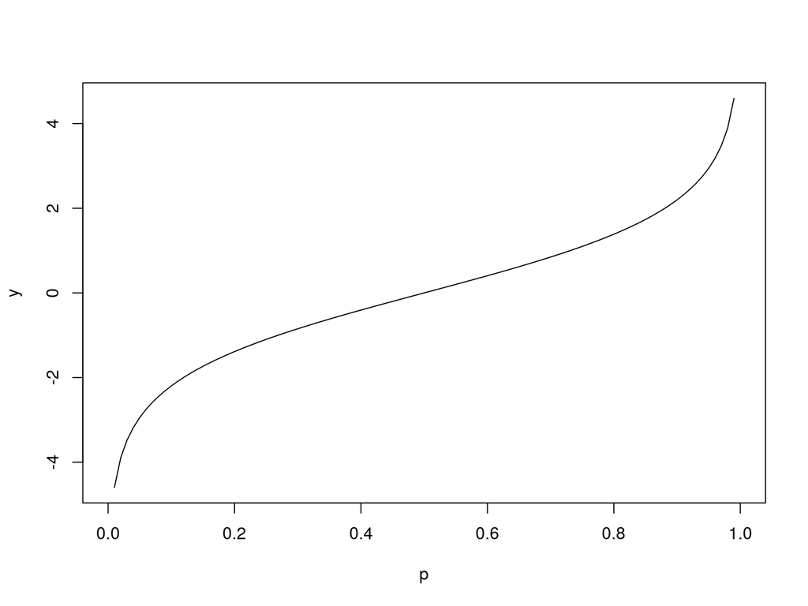

```r
p <- seq(0, 1, by = 0.01)
y <- qlogis(p)
plot(p, y, type = "l")
```

### Part II, Survival Analysis Intro

- Survival data is unique in that the true survival time may be censored.
- $T_i$: the time to event for the ith individual.
- $C_i$: the corresponding censoring time.
- We observe $Y_i = \min(T_i, C_i)$ and $\delta_i = I(T_i \leq C_i)$ (i.e. $\delta_i = 1$ if $T_i \leq C_i$ and $\delta_i = 0$ if $T_i > C_i$).
- We also have predictors $X_i$ for each individual.

### Part II, Q6: Kaplan-Meier Curve

- A way to estimate the *survival function* $P(T_i > t)$ from our observed data, taking into account the censoring.
- We pass in $Y_i$ and $\delta_i$ into the `Surv` function.

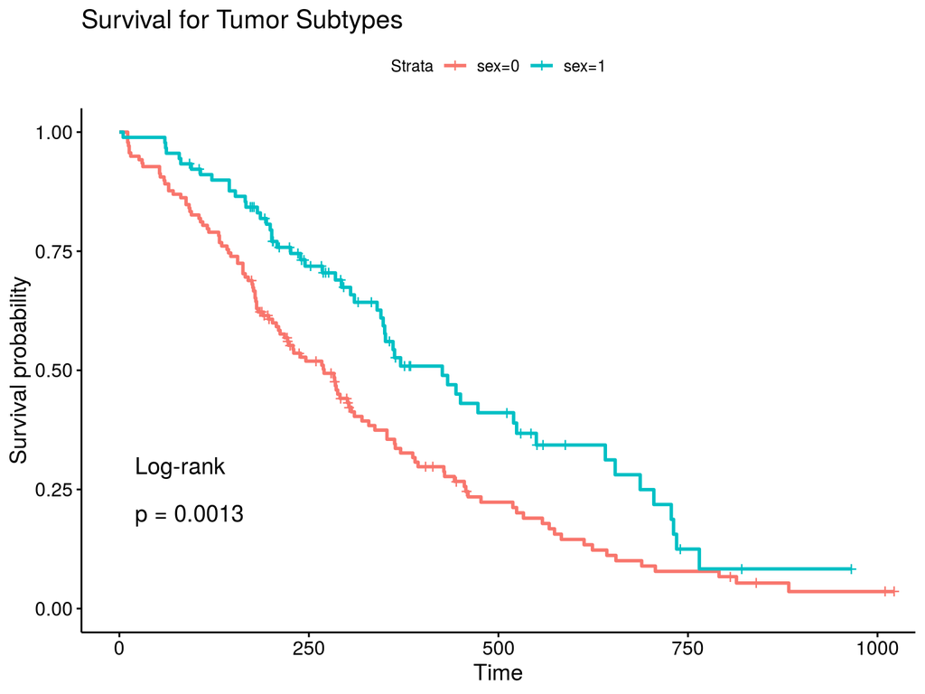

```r
# using lung data from survival package
# data wrangling to make this easier
lung2 <- lung
# 1 = died, 0 = still alive at last observation
lung2$death <- lung$status - 1
lung2$sex <- lung2$sex - 1

km_fit <- survfit(Surv(time, death) ~ sex, data = lung2)
ggsurvplot(km_fit, pval = TRUE, pval.method = TRUE) +
    ggtitle("Survival for Tumor Subtypes")
```

### Part II, Q6: Logrank test

- The log-rank test compares the survival curves across the observed time frame. Significant p-value means the two curves are different.

```r
survdiff(Surv(time, death) ~ sex, data = lung2)
```

```
## Call:
## survdiff(formula = Surv(time, death) ~ sex, data = lung2)
##
##         N Observed Expected (O-E)^2/E (O-E)^2/V
## sex=0 138      112     91.6      4.55      10.3
## sex=1  90       53     73.4      5.68      10.3
##
##  Chisq= 10.3  on 1 degrees of freedom, p= 0.001
```

### Part II, Q7: Cox Regression

- The hazard function $\lambda(t)$ is defined as $\lambda(t) = \lim_{\delta \to 0} \frac{1}{\delta} P(t \leq T < t + \delta | T \geq t)$.
- Interpretation: instantaneous rate at time $t$, given that the event has not occurred prior to time $t$.
- Cox proportional hazards model: $\lambda(t_i) = \lambda_0(t_i) \exp( X_1 \beta_1 + \cdots + X_p \beta_p)$.
- We are only interested in the $\beta$’s
- We can perform estimation and inference without specifying $\lambda_0(t_i)$. $\lambda_0(t_i)$ is the hazard when all $X_i = 0$, and is called the baseline hazard.
- The likelihood ratio/score/wald test output shows the predictive power of the model, compared to a model without any covariates.
- Significant p-value indicates model is performing better than model without any covariates.

### Part II, Q7: Cox Regression Code

```r
cox_mod1 <- coxph(Surv(time, death) ~ sex, data = lung2)
summary(cox_mod1)
```

```
## Call:
## coxph(formula = Surv(time, death) ~ sex, data = lung2)
##
##   n= 228, number of events= 165
##
##        coef exp(coef) se(coef)      z Pr(>|z|)
## sex -0.5310    0.5880   0.1672 -3.176  0.00149 **
## ---
## Signif. codes:  0 '***' 0.001 '**' 0.01 '*' 0.05 '.' 0.1 ' ' 1
##
##     exp(coef) exp(-coef) lower .95 upper .95
## sex     0.588      1.701    0.4237     0.816
##
## Concordance= 0.579  (se = 0.021 )
## Rsquare= 0.046   (max possible= 0.999 )
## Likelihood ratio test= 10.63  on 1 df,   p=0.001
## Wald test            = 10.09  on 1 df,   p=0.001
## Score (logrank) test = 10.33  on 1 df,   p=0.001
```

```r
cox_mod2 <- coxph(Surv(time, death) ~ sex + age + ph.ecog, data = lung2)
summary(cox_mod2)
```

```
## Call:
## coxph(formula = Surv(time, death) ~ sex + age + ph.ecog, data = lung2)
##
##   n= 227, number of events= 164
##    (1 observation deleted due to missingness)
##
##              coef exp(coef)  se(coef)      z Pr(>|z|)
## sex     -0.552612  0.575445  0.167739 -3.294 0.000986 ***
## age      0.011067  1.011128  0.009267  1.194 0.232416
## ph.ecog  0.463728  1.589991  0.113577  4.083 4.45e-05 ***
## ---
## Signif. codes:  0 '***' 0.001 '**' 0.01 '*' 0.05 '.' 0.1 ' ' 1
##
##         exp(coef) exp(-coef) lower .95 upper .95
## sex        0.5754     1.7378    0.4142    0.7994
## age        1.0111     0.9890    0.9929    1.0297
## ph.ecog    1.5900     0.6289    1.2727    1.9864
##
## Concordance= 0.637  (se = 0.025 )
## Rsquare= 0.126   (max possible= 0.999 )
## Likelihood ratio test= 30.5  on 3 df,   p=1e-06
## Wald test            = 29.93  on 3 df,   p=1e-06
## Score (logrank) test = 30.5  on 3 df,   p=1e-06
```

### Part II, Q7: LASSO for Cox Regression

- We can also apply LASSO to the Cox proportional hazards model when we have too many predictors and/or we want to do model selection.
- Code is very similar to previous code for glmnet: plug in a **matrix** of predictors and a **vector** of responses. Note the `family = "cox"` argument.
- Because we have more differential genes than samples in the HW, we will need to use LASSO to select the relevant genes before fitting the Cox model.

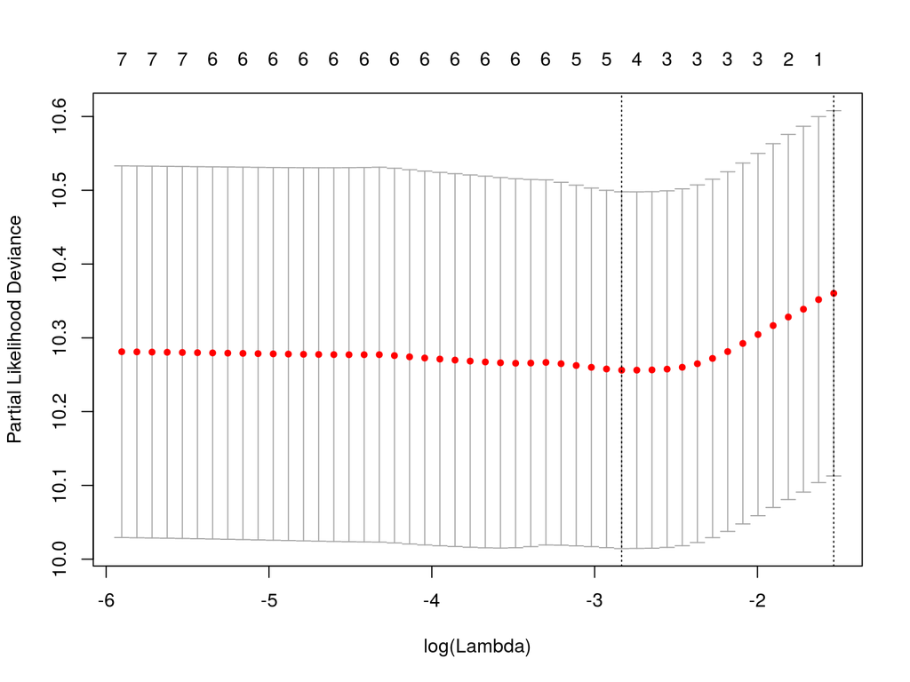

```r
lung_nona <- na.omit(lung2)
x <- as.matrix(lung_nona[,4:10])
survobj <- Surv(lung_nona$time, lung_nona$death)
cvfit <- cv.glmnet(x, survobj, family = "cox")
plot(cvfit)
```

```r
coef(cvfit, s = "lambda.min")
```

```
## 7 x 1 sparse Matrix of class "dgCMatrix"
##                      1
## age        .
## sex       -0.319172743
## ph.ecog    0.308692537
## ph.karno   .
## pat.karno -0.004774923
## meal.cal   .
## wt.loss   -0.001966300
```

### Part II, Q8: Data Wrangling

- In your HW, you will have to merge data from two different datasets.
- Practice: merge the survival information in `lung_surv` with the predictors in `lung_predictors`. Use the rownames (`id_##`) to distinguish between different subjects.

```r
set.seed(0)
rownames(lung2) <- paste0("id_", 1:nrow(lung2))
lung_surv <- lung2[, c("time", "death")]
lung_predictors <- select(lung2, -time, -death, -status)
lung_predictors <- lung_predictors[order(lung_predictors$ph.ecog),]
random_predictors <- matrix(rnorm(20 * nrow(lung2)), ncol = 20)
colnames(random_predictors) <- paste0("predictor_", 1:20)
lung_predictors <- cbind(lung_predictors, random_predictors)

lung_predictors[1:5, 1:5]
```

```
##       inst age sex ph.ecog ph.karno
## id_2     3  68   0       0       90
## id_3     3  56   0       0       90
## id_5     1  60   0       0      100
## id_22    6  49   1       0      100
## id_24   15  58   0       0       90
```

```r
lung_surv[1:5,]
```

```
##      time death
## id_1  306     1
## id_2  455     1
## id_3 1010     0
## id_4  210     1
## id_5  883     1
```

```r
# merge the predictors with the survival information so you can
# run a Cox regression using the predictors sex + ph.ecog
lung3 <- merge(lung_surv, lung_predictors, by = "row.names")
lung3[1:5, 1:5]
```

```
##   Row.names time death inst age
## 1      id_1  306     1    3  74
## 2     id_10  166     1    7  61
## 3    id_100  166     1    3  70
## 4    id_101  559     0    1  58
## 5    id_102  450     1    6  69
```

```r
cox_mod3 <- coxph(Surv(time, death) ~ sex + ph.ecog, data = lung3)
summary(cox_mod3)
```

```
## Call:
## coxph(formula = Surv(time, death) ~ sex + ph.ecog, data = lung3)
##
##   n= 227, number of events= 164
##    (1 observation deleted due to missingness)
##
##            coef exp(coef) se(coef)      z Pr(>|z|)
## sex     -0.5530    0.5752   0.1676 -3.300 0.000967 ***
## ph.ecog  0.4875    1.6282   0.1122  4.344  1.4e-05 ***
## ---
## Signif. codes:  0 '***' 0.001 '**' 0.01 '*' 0.05 '.' 0.1 ' ' 1
##
##         exp(coef) exp(-coef) lower .95 upper .95
## sex        0.5752     1.7384    0.4142    0.7989
## ph.ecog    1.6282     0.6142    1.3067    2.0288
##
## Concordance= 0.642  (se = 0.025 )
## Rsquare= 0.12   (max possible= 0.999 )
## Likelihood ratio test= 29.05  on 2 df,   p=5e-07
## Wald test            = 28.96  on 2 df,   p=5e-07
## Score (logrank) test = 29.41  on 2 df,   p=4e-07
```

### Part II, Q8: Randomly selecting predictors

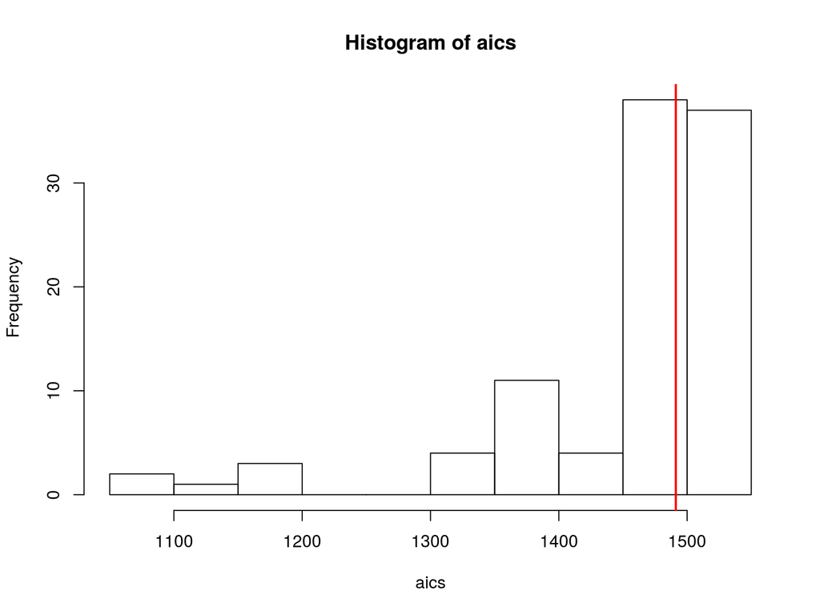

```r
set.seed(20180410)
aics <- rep(NA, 100)
for (i in 1:100) {
    # sample which predictors you want to use
    pred_index <- sample(1:ncol(lung_predictors), 3, replace = FALSE)
    # subset the predictors
    predictors_touse <- lung_predictors[, pred_index]
    # merge predictors with survival information
    data_touse <- merge(lung2[, c("time", "death")], predictors_touse,
                        by = "row.names")
    data_touse$Row.names <- NULL
    # fit the model
    mod <- coxph(Surv(time, death) ~ ., data = data_touse)
    # extract the AIC
    aics[i] <- AIC(mod)
}

# visualize
hist(aics)
abline(v = AIC(cox_mod1), lwd = 2, col = "red")
```

```r
mean(aics < AIC(cox_mod1))
```

```
## [1] 0.51
```

## Part III, Q1: Counting mutations

- Count up how many mutations are present in all the patients, and group by subtype.
- What counts as a mutation? Count mutations with the exact same amino acid change as the same.
- The amino acid change is given in the `Protein_Change` column.

### Part III, Q1: How to Count

- Will need to tell Python about which samples belong to which subtype.
- Can hardcode it or write a csv file from R and read that in with Python.
- Tip: check out the `Counter` class from the `collections` module in Python.

```
# Tally occurrences of words in a list
cnt = Counter()
for word in ['red', 'blue', 'red', 'green', 'blue', 'blue']:
    cnt[word] += 1
cnt
## Counter({'blue': 3, 'red': 2, 'green': 1})
```

- You can do math things like add up two `Counter` objects.
- Check out the documentation here: https://docs.python.org/2/library/collections.html

### Part III, Q3-Q5, in case you want to get started

- Will be covered next lab.
- Do not need to use maf2vcf function. The maf2vcf function is pretty annoying to install.
- You don’t need to use VCF as input (although this is what you would used in an actual sequencing study). The simple input format is like: “TR1 chr22 30025797 + A T sample_1”
- Columns are UID, chromosome, position (1-based), strand, reference base(s), alternate base(s), and (optional) sample ID, separated by a space or tab. UID should not contain commas. For indels, use the following format with “-” means no base.
- This simple input format could probably be prepared through a shell one-liner on the MAF file. Concatenating the simple input format for each maf should then be a relatively straightforward use of the “cat” command in linux.

### Part III, Q6-Q9

- Involves using web tools.
- Show screenshots of your results and describe how you used the tool (e.g. inputs that you specified).
- See lecture slides for how to interpret results (e.g. which gene is a driver gene, loss of function or gain of function).

**Installation on local computer**:

1. Download the source code from SourceForge.
2. Uncompress the source code, e.g. `tar -zxvf mageck-0.5.7.tar.gz`
3. `cd` into the folder where the source code is.
4. Run the installation: `python setup.py install`

**Installation on Odyssey**:

1. Copy the folder `/n/stat115/HW6_2019/mageck-0.5.8` to your home directory: `cp -r /n/stat115/HW6_2019/mageck-0.5.8 ~`
2. `cd ~/mageck-0.5.8`
3. `module load Anaconda/5.0.1-fasrc01`
4. `python setup.py install --user`
5. Test that the command works with `mageck --help`

Might get `command not found`. Try running `nano ~/.bash_profile` to edit the file `~/.bash_profile` and add the following 2 lines:

```
PATH=$PATH:$HOME/.local/bin:$HOME/bin
export PATH
```

Save and quit, and then run `source ~/.bash_profile`

### How to Run

- First, have to convert the fastq files into counts for each gene.

```
mageck count -l library.csv -n OUT --sample-label Day0,Day23 \
--fastq Day0_Rep1.fastq.gz,Day0_Rep2.fastq.gz Day23_Rep1.fastq.gz,Day23_Rep2.fastq.gz
```

- Then, test if the counts are significant or not.

```
mageck test -k OUT.count.txt -t Day23 -c Day0 -n OUT
```

### Part IV, Q1: Running on Odyssey

- Sample slurm script

```
#!/bin/bash
#SBATCH -n 1 # Number of cores
#SBATCH -N 1 # Ensure that all cores are on one machine
#SBATCH -t 0-06:00 # Runtime in D-HH:MM
#SBATCH -p serial_requeue # Partition to submit to
#SBATCH --mem=1000 # Memory pool for all cores (see also --mem-per-cpu)
#SBATCH -o mageck.out # File to which STDOUT will be written
#SBATCH -e mageck.err # File to which STDERR will be written
#SBATCH --mail-type=ALL
#SBATCH --mail-user="YOUR_EMAIL@harvard.edu"

module load Anaconda/5.0.1-fasrc01

# your code here
```

### Part IV, Q1: Basic QC for Read Mapping

Look at the `countsummary.txt` file generated after `mageck count`. Look at documentation here for guide to QC metrics: https://sourceforge.net/p/mageck/wiki/output/

- Percentage of reads mapped to be above 0.6.
- Zero counts less than 0.1.
- Gini index less than 0.1.
- Can check out the MAGeCKFlute package on Bioconductor for plots.
- https://bioconductor.org/packages/release/bioc/html/MAGeCKFlute.html

### Part IV, Q1: Basic QC for Ribosomal Genes

- This file contains the genes ranked by how negatively selected they are (most to least).
- Ribosomal genes start with “RP”, so you can get all the rows that have ribosomal genes using `grepl("^RP", genesummary$id)` on the `id` column of the `genesummary.txt` file.
- Another check: look at the results from DAVID. Do you see functional annotation clusters for ribosomal activity, e.g. protein synthesis?

### Part IV, Q1: Basic QC for Replicate Consistency

- Count each replicate separately.
- The resultant `count.txt` file will contain one column for each of the 4 samples.
- Plot the counts for Rep1 against Rep2 and look at the correlation.
- It should be fairly high.
- Code to count separately:

```
mageck count -l library.csv -n OUT_SEPARATE --sample-label Day0_Rep1,Day0_Rep2,Day23_Rep1,Day23_Rep2 \
--fastq Day0_Rep1.fastq.gz Day0_Rep2.fastq.gz Day23_Rep1.fastq.gz Day23_Rep2.fastq.gz
```

### Part IV, Q2: Which genes are positively or negatively selected?

- Take a look at the `gene_summary.txt` file.
- Can filter by positive selection FDR adjusted pvalue and negatively selection FDR adjusted pvalue.
- See MAGeCKFlute vignette for plots and pathway analysis:
- https://bioconductor.org/packages/release/bioc/vignettes/MAGeCKFlute/inst/doc/MAGeCKFlute.html

### Part IV, Q3-Q4

- Q3: Using an online tool.
- Q4: Remove genes that are in the `PanEssential.txt` file.
  - Pseudocode: `neg_genes[!(neg_genes %in% essential_genes)]`
- Sort by p-value.
  - `neg_genes_df[order(neg_genes_df$pvalue),]`
- Take the top 10 and paste it in the OASIS genomics website.
  - Make sure you select `GBM` for the disease.

### Part V

- Mostly using websites.
- Again, explain your steps and show screenshots.